# Data Science for Public Policy

Assignment 04

Author

Priscila Stisman - prs62 & Maleeha Hameed - mh2203

## **Exercise 3.**

**Try to git add your data file. What message do you receive in the terminal?**

#hint: Use -f if you really want to add them. #hint: Turn this message off by running #hint: “git config advice.addIgnoredFile false” #The `echo: false` option disables the printing of code (only output is displayed).

```r
# Library setup
library (tidyverse)
library (dplyr)
library(ggplot2)
library(ggthemes)
library(readr)
library (haven)
```

## **Exercise 4**

Our visualizations are based on the Quality of Government (QoG) Institute Basic Dataset 2023 (QoG, 2023). This dataset contains cross-sectional and time-series from 194 countries between 2000 and 2021.

```r
# Read data
data <- read_dta("Data/idm_qog.dta")
```

#### Graph 1: People in countries with higher GDP per capita live longer

This scatter plot shows the correlation between the log of the GDP per capita (in US dollars) and the life expectancy in years for 194 countries. Except for a few outliers with a higher life expectancy for a lower GDP per capita, we find a linear correlation (denoted by a line of best fit) between countries with higher GDP per capita and their life expectancy in years. This graph confirms the success story of many developed countries, globally, where people live longer than 75 years of age, on average, given higher annual earnings.

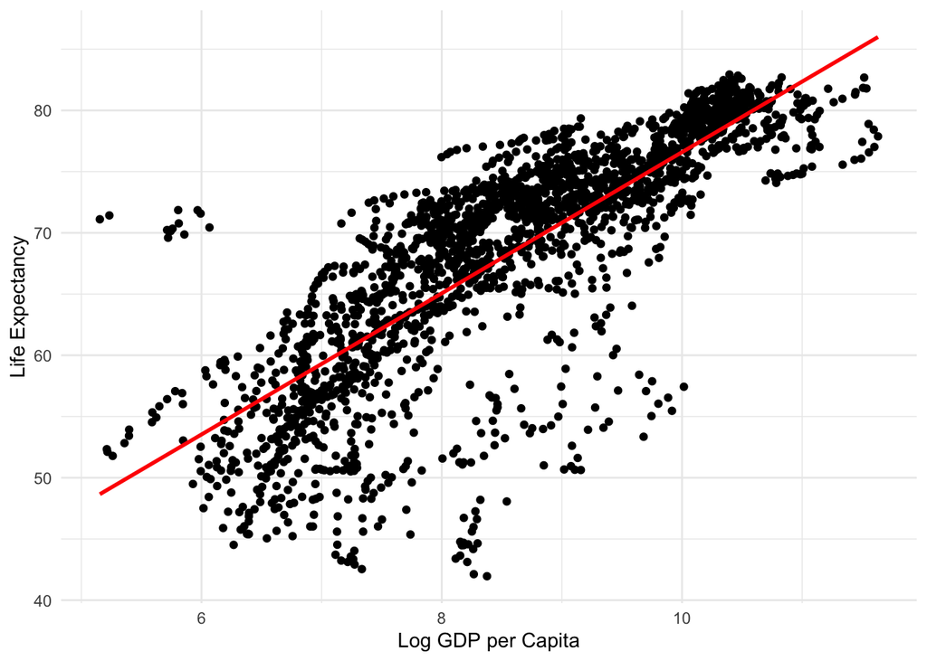

```r
# Graph 1

data %>%
  ggplot() +
    geom_point(aes(x = log(gle_cgdpc), y =wdi_lifexp)) +
  geom_smooth(aes(x = log(gle_cgdpc), y = wdi_lifexp), method = "lm", se = FALSE, color = "red") +
  theme_minimal() +
   xlab("Log GDP per Capita") +  # Set x-axis label
  ylab("Life Expectancy")      # Set y-axis label
```

#### Graph 2: Countries with higher GDP per capita contribute more to climate change

A higher GDP per capita does not always tell an optimistic story! With climate change increasingly becoming a pressing global policy issue, we want to draw attention to the correlation between countries with a higher GDP per capita and their contribution to a higher carbon footprint of production per year. We use the color scale gradient from light blue to indigo and the size of the circle to show the variation in the carbon footprint of production.

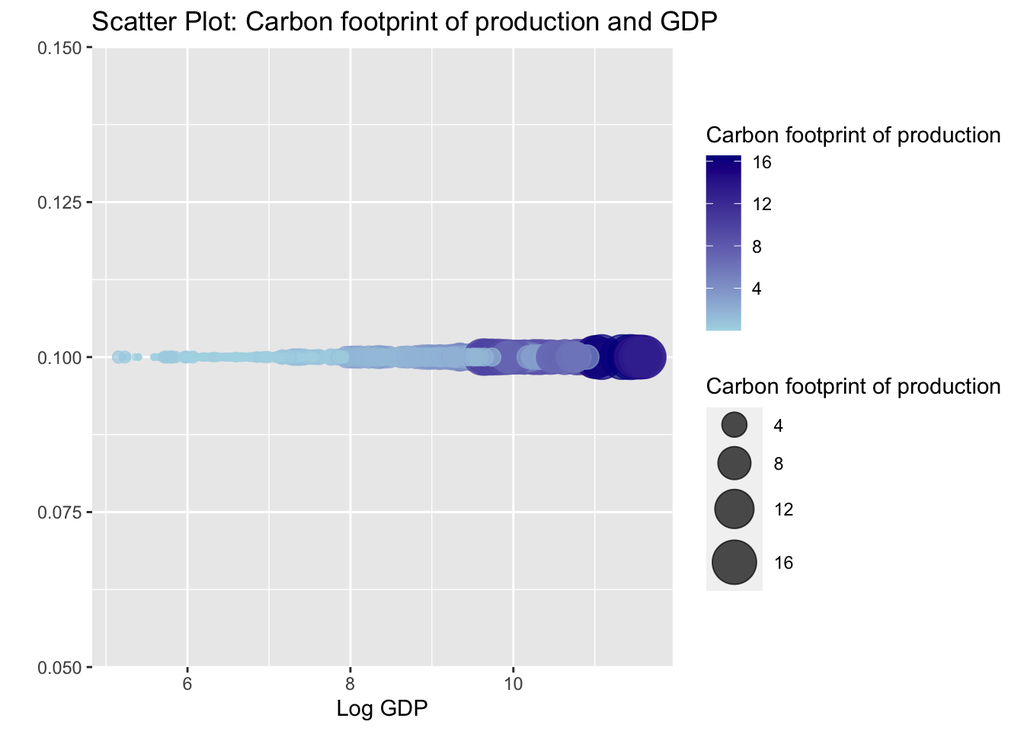

```r
# Graph 2

ggplot(data, aes(x = log(gle_cgdpc), y = 0.1, size = ef_carbp, color = ef_carbp), na.rm = TRUE) +
  geom_point(alpha = 0.7) +
  scale_size_continuous(range = c(1, 10)) +
  scale_color_gradient(low = "lightblue", high = "darkblue") +
  labs(title = "Scatter Plot: Carbon footprint of production and GDP",
       x = "Log GDP",
       y = "",
       size = "Carbon footprint of production",
       color = "Carbon footprint of production") +
  guides(size = guide_legend(title = "Carbon footprint of production"))
```

#### Graph 3: Cross region variation in how long people live

Except for Sub Saharan Africa, the rest of the 9 regions of the world have an average life expectancy of greater than 60 years. North America and Western Europe, where most developed countries are located, fare the highest on the average life expectancy. We do not observe much variation in life expectancy over time across the different regions as most of the variation can be observed at the inter-country level. This graph reinforces the findings from Graph 1.

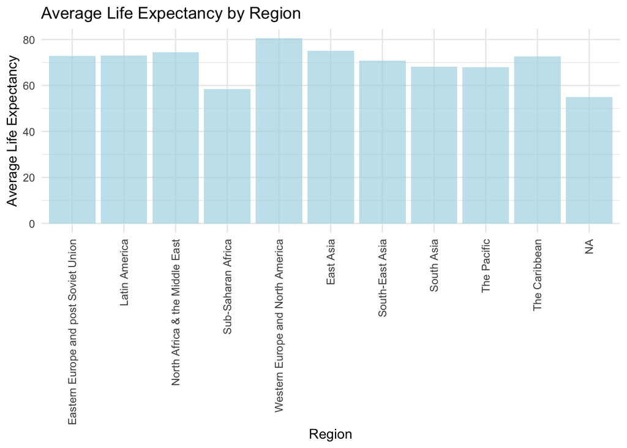

```r
# Graph 3
library(ggplot2)

# Assuming your data frame is named data
ggplot(data, aes(x = factor(ht_region), y = wdi_lifexp, fill = wdi_lifexp)) +
  stat_summary(fun = "mean", geom = "bar", fill = "lightblue", alpha = 0.7) +
  labs(title = "Average Life Expectancy by Region",
       x = "Region",
       y = "Average Life Expectancy") +
  theme_minimal() +
  scale_x_discrete(labels = c("Eastern Europe and post Soviet Union", "Latin America", "North Africa & the Middle East", "Sub-Saharan Africa", "Western Europe and North America", "East Asia", "South-East Asia", "South Asia", "The Pacific", "The Caribbean"))+
  theme(axis.text.x = element_text(angle = 90, vjust = 0.5, hjust = 1))
```

#### Graph 4: Women make less than 50% of the labor force globally

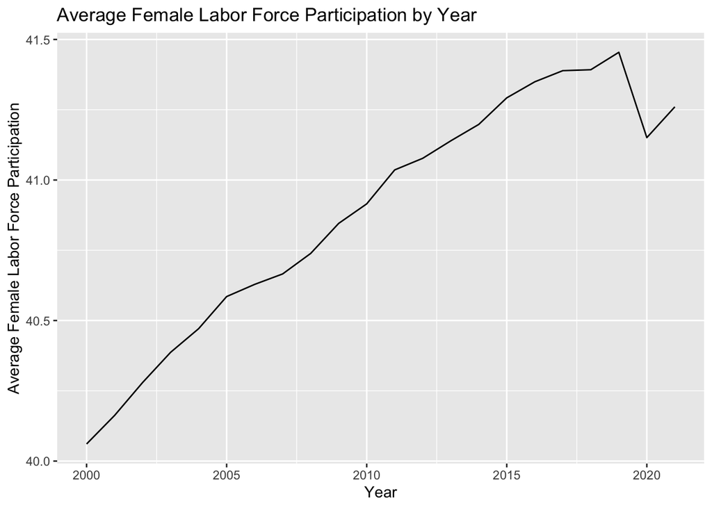

```r
# Graph 4

average_female_labor_participation <- data %>%
  group_by(year) %>%
  summarize(avg_female_labor_participation = mean(wdi_lfpf, na.rm = TRUE))

# Plotting the line plot
ggplot(average_female_labor_participation, aes(x = year, y = avg_female_labor_participation)) +
  geom_line() +
  labs(title = "Average Female Labor Force Participation by Year",
       x = "Year",
       y = "Average Female Labor Force Participation")
```

## *References*

Dahlberg, Stefan, Aksel Sundström, Sören Holmberg, Bo Rothstein, Natalia Alvarado Pachon, Cem Mert Dalli & Yente Meijers. 2023. The Quality of Government Basic Dataset, version Jan23. University of Gothenburg: The Quality of Government Institute, https://www.gu.se/en/quality-government doi:10.18157/qogbasjan23